# R Notebook for Cyclic data analysis

## Introduction

This is my version of the Google Data Analytics Capstone - Case study 01. The full documents for the case study can be found in the Google Data Analytics Capstone Project : Complete a Case Study course

For this project I will follow the steps of data analysis process:

- Ask
- Prepare
- Process
- Analyze
- Share
- Act

### Ask

#### What is the problem we are trying to solve?

Design marketing strategies aimed at converting casual riders into annual members.

#### What is the business question?

“How do annual members and casual riders use Cyclistic bikes differently?”

#### How can y insights drive business decisions?

The insights will help the marketing team to increase annual members.

#### Identify key Stakeholders

Cyclistic executive team: The notoriously detail-oriented executive team will decide whether to approve the recommended marketing program.

Lily Moreno: The director of marketing and your manager

### Prepare

#### Where is data is located?

The data is located in the link provided by Google and we can find it in Kaggle also.

#### How is the data organized?

The data is separated by month, each on it’s own csv.

#### Are there issues with bias or credibility in this data? Does your data is ROCCC?

In this case bias won’t be a problem because the population of the datasetnis it’s own clients as bike riders. And have full credibility for the same reason. And finally, it’s ROCCC because it is reliable, original, comprehensive, curent and cited.

#### How did you verify the data’s integrity? And how did you answer your question?

All the files have consistent columns and each column has the correct type of data.It may have some key insights about the riders and their riding style.

### Process

#### Overview

- Manipulating the data

  New columns will help improve calculation time in the future

01 : Load all of the libraries : * tidyverse for calculations * lubridate for deal with dates * hms to deal with time * data.table to exporting data frame

Load Libraries

```r
library(tidyverse)
library(lubridate)
library(hms)
library(data.table)
```

```r
aug08_df <-  read.csv("Trip_data_csv/202108-divvy-tripdata.csv")
sep09_df <-  read.csv("Trip_data_csv/202109-divvy-tripdata.csv")
oct10_df <-  read.csv("Trip_data_csv/202110-divvy-tripdata.csv")
nov11_df <-  read.csv("Trip_data_csv/202111-divvy-tripdata.csv")
dec12_df <-  read.csv("Trip_data_csv/202112-divvy-tripdata.csv")
jan01_df <-  read.csv("Trip_data_csv/202201-divvy-tripdata.csv")
feb02_df <-  read.csv("Trip_data_csv/202202-divvy-tripdata.csv")
mar03_df <-  read.csv("Trip_data_csv/202203-divvy-tripdata.csv")
apr04_df <-  read.csv("Trip_data_csv/202204-divvy-tripdata.csv")
may05_df <-  read.csv("Trip_data_csv/202205-divvy-tripdata.csv")
jun06_df <-  read.csv("Trip_data_csv/202206-divvy-tripdata.csv")
jul07_df <-  read.csv("Trip_data_csv/202207-divvy-tripdata.csv")
```

03 : Merged the 12 months of data together using rbind to create a one year view

```r
cyclistic_df <- rbind(aug08_df, sep09_df, oct10_df, nov11_df, dec12_df, jan01_df, feb02_df, mar03_df, apr04_df, may05_df, jun06_df, jul07_df)
```

04 : Remove individual month data frames to clear up space in the environment

```r
remove(aug08_df, sep09_df, oct10_df, nov11_df, dec12_df, jan01_df, feb02_df, mar03_df, apr04_df, may05_df, jun06_df, jul07_df)
```

Have a look on the dataset

```r
head(cyclistic_df)
```

|  | ride_id | rideable_type | started_at | ended_at | start_station_name | start_station_id | end_station_name | end_station_id | start_lat | start_lng | end_lat | end_lng | member_casual |
| --- | --- | --- | --- | --- | --- | --- | --- | --- | --- | --- | --- | --- | --- |
| 1 | 99103BB87CC6C1BB | electric_bike | 2021-08-10 17:15:49 | 2021-08-10 17:22:44 |  |  |  |  | 41.77 | -87.68 | 41.77 | -87.68 | member |
| 2 | EAFCCCFB0A3FC5A1 | electric_bike | 2021-08-10 17:23:14 | 2021-08-10 17:39:24 |  |  |  |  | 41.77 | -87.68 | 41.77 | -87.63 | member |
| 3 | 9EF4F46C57AD234D | electric_bike | 2021-08-21 02:34:23 | 2021-08-21 02:50:36 |  |  |  |  | 41.95 | -87.65 | 41.97 | -87.66 | member |
| 4 | 5834D3208BFAF1DA | electric_bike | 2021-08-21 06:52:55 | 2021-08-21 07:08:13 |  |  |  |  | 41.97 | -87.67 | 41.95 | -87.65 | member |
| 5 | CD825CB87ED1D096 | electric_bike | 2021-08-19 11:55:29 | 2021-08-19 12:04:11 |  |  |  |  | 41.79 | -87.60 | 41.77 | -87.62 | member |
| 6 | 612F12C94A964F3E | electric_bike | 2021-08-19 12:41:12 | 2021-08-19 12:47:47 |  |  |  |  | 41.81 | -87.61 | 41.80 | -87.60 | member |

```r
nrow(cyclistic_df)
```

```
## [1] 5901463
```

05 : Created a new data frame called cyclistic_date that would contain all of my new columns

```r
cyclistic_date <- cyclistic_df
```

06 : Created new columns for :

```r
#calculate ride length by subtracting ended_at time from started_at time and converted it to minutes
cyclistic_date$ride_length <- difftime(cyclistic_date$ended_at , cyclistic_date$started_at, units = "mins")
```

```r
#create columns for: day of week, month, day, year, time, hour
cyclistic_date$date <- as.Date(cyclistic_date$started_at)
```

```r
#calculate the day of the week
cyclistic_date$day_of_the_week <- wday(cyclistic_df$started_at)
#create the column for day of the week
cyclistic_date$day_of_the_week <- format(as.Date(cyclistic_date$date), "%A")
```

```r
#create the column for month
cyclistic_date$month <- format(as.Date(cyclistic_date$date), "%m")
```

```r
#create the column for day
cyclistic_date$day <- format(as.Date(cyclistic_date$date), "%d")
```

```r
#create the column for day of the week
cyclistic_date$year <- format(as.Date(cyclistic_date$date), "%y")
```

```r
#create the column for start_hour
cyclistic_date <- cyclistic_date %>%
  mutate(start_hour = strftime(cyclistic_date$started_at, "%H"))
```

```r
#create column for different seasons: Spring, Summer, Fall, Winter
cyclistic_date <-cyclistic_date %>%
    mutate(season = case_when(month == "03" ~ "Spring",
                              month == "04" ~ "Spring",
                              month == "05" ~ "Spring",
                              month == "06"  ~ "Summer",
                              month == "07"  ~ "Summer",
                              month == "08"  ~ "Summer",
                              month == "09" ~ "Fall",
                              month == "10" ~ "Fall",
                              month == "11" ~ "Fall",
                              month == "12" ~ "Winter",
                              month == "01" ~ "Winter",
                              month == "02" ~ "Winter")
    )
```

```r
#create column for different time_of_day: Night, Morning, Afternoon, Evening
cyclistic_date <-cyclistic_date %>%
    mutate(time_of_day = case_when(start_hour == "00" ~ "Night",
                                  start_hour == "01" ~ "Night",
                                  start_hour == "02" ~ "Night",
                                  start_hour == "03" ~ "Night",
                                  start_hour == "04" ~ "Night",
                                  start_hour == "05" ~ "Night",
                                  start_hour == "06" ~ "Morning",
                                  start_hour == "07" ~ "Morning",
                                  start_hour == "08" ~ "Morning",
                                  start_hour == "09" ~ "Morning",
                                  start_hour == "10" ~ "Morning",
                                  start_hour == "11" ~ "Morning",
                                  start_hour == "12" ~ "Afternoon",
                                  start_hour == "13" ~ "Afternoon",
                                  start_hour == "14" ~ "Afternoon",
                                  start_hour == "15" ~ "Afternoon",
                                  start_hour == "16" ~ "Afternoon",
                                  start_hour == "17" ~ "Afternoon",
                                  start_hour == "18" ~ "Evening",
                                  start_hour == "19" ~ "Evening",
                                  start_hour == "20" ~ "Evening",
                                  start_hour == "21" ~ "Evening",
                                  start_hour == "22" ~ "Evening",
                                  start_hour == "23" ~ "Evening")
    )
```

check the dataset

```r
head(cyclistic_date)
```

|  | ride_id | rideable_type | started_at | ended_at | start_station_name | start_station_id | end_station_name | end_station_id | start_lat | start_lng | end_lat | end_lng | member_casual | ride_length | date | day_of_the_week | month | day | year | start_hour | season | time_of_day |
| --- | --- | --- | --- | --- | --- | --- | --- | --- | --- | --- | --- | --- | --- | --- | --- | --- | --- | --- | --- | --- | --- | --- |
| 1 | 99103BB87CC6C1BB | electric_bike | 2021-08-10 17:15:49 | 2021-08-10 17:22:44 |  |  |  |  | 41.77 | -87.68 | 41.77 | -87.68 | member | 6.916667 mins | 2021-08-10 | Tuesday | 08 | 10 | 21 | 17 | Summer | Afternoon |
| 2 | EAFCCCFB0A3FC5A1 | electric_bike | 2021-08-10 17:23:14 | 2021-08-10 17:39:24 |  |  |  |  | 41.77 | -87.68 | 41.77 | -87.63 | member | 16.166667 mins | 2021-08-10 | Tuesday | 08 | 10 | 21 | 17 | Summer | Afternoon |
| 3 | 9EF4F46C57AD234D | electric_bike | 2021-08-21 02:34:23 | 2021-08-21 02:50:36 |  |  |  |  | 41.95 | -87.65 | 41.97 | -87.66 | member | 16.216667 mins | 2021-08-21 | Saturday | 08 | 21 | 21 | 02 | Summer | Night |
| 4 | 5834D3208BFAF1DA | electric_bike | 2021-08-21 06:52:55 | 2021-08-21 07:08:13 |  |  |  |  | 41.97 | -87.67 | 41.95 | -87.65 | member | 15.300000 mins | 2021-08-21 | Saturday | 08 | 21 | 21 | 06 | Summer | Morning |
| 5 | CD825CB87ED1D096 | electric_bike | 2021-08-19 11:55:29 | 2021-08-19 12:04:11 |  |  |  |  | 41.79 | -87.60 | 41.77 | -87.62 | member | 8.700000 mins | 2021-08-19 | Thursday | 08 | 19 | 21 | 11 | Summer | Morning |
| 6 | 612F12C94A964F3E | electric_bike | 2021-08-19 12:41:12 | 2021-08-19 12:47:47 |  |  |  |  | 41.81 | -87.61 | 41.80 | -87.60 | member | 6.583333 mins | 2021-08-19 | Thursday | 08 | 19 | 21 | 12 | Summer | Afternoon |

```r
nrow(cyclistic_date)
```

```
## [1] 5901463
```

- Data cleaning

  Cleaned the data by:
  - Removing duplicate rows
  - Remove rows with NA values (blank rows)
  - Remove where ride_length is 0 or negative (ride_length should be a positive number)
  - Remove unnecessary columns:start_station_id, end_station_id, start_lat, start_long, end_lat, end_lng

```r
#remove duplicate values
cyclistic_date <- distinct(cyclistic_date)
nrow(cyclistic_date)
```

```
## [1] 5901463
```

```r
#remove rows with NA values
cyclistic_date <- na.omit(cyclistic_date)
nrow(cyclistic_date)
```

```
## [1] 5895873
```

```r
#remove where ride length is 0 or negative
cyclistic_date <- cyclistic_date[!(cyclistic_date$ride_length <= 0), ]
nrow(cyclistic_date)
```

```
## [1] 5895237
```

```r
colnames(cyclistic_date)
```

```
##  [1] "ride_id"            "rideable_type"      "started_at"
##  [4] "ended_at"           "start_station_name" "start_station_id"
##  [7] "end_station_name"   "end_station_id"     "start_lat"
## [10] "start_lng"          "end_lat"            "end_lng"
## [13] "member_casual"      "ride_length"        "date"
## [16] "day_of_the_week"    "month"              "day"
## [19] "year"               "start_hour"         "season"
## [22] "time_of_day"
```

```r
#Remove unnecessary columns
cyclistic <- subset(cyclistic_date, select = -c(start_station_name, start_station_id, end_station_name, end_station_id,start_lat,start_lng,end_lat,end_lng))
```

```r
head(cyclistic)
```

|  | ride_id | rideable_type | started_at | ended_at | member_casual | ride_length | date | day_of_the_week | month | day | year | start_hour | season | time_of_day |
| --- | --- | --- | --- | --- | --- | --- | --- | --- | --- | --- | --- | --- | --- | --- |
| 1 | 99103BB87CC6C1BB | electric_bike | 2021-08-10 17:15:49 | 2021-08-10 17:22:44 | member | 6.916667 mins | 2021-08-10 | Tuesday | 08 | 10 | 21 | 17 | Summer | Afternoon |
| 2 | EAFCCCFB0A3FC5A1 | electric_bike | 2021-08-10 17:23:14 | 2021-08-10 17:39:24 | member | 16.166667 mins | 2021-08-10 | Tuesday | 08 | 10 | 21 | 17 | Summer | Afternoon |
| 3 | 9EF4F46C57AD234D | electric_bike | 2021-08-21 02:34:23 | 2021-08-21 02:50:36 | member | 16.216667 mins | 2021-08-21 | Saturday | 08 | 21 | 21 | 02 | Summer | Night |
| 4 | 5834D3208BFAF1DA | electric_bike | 2021-08-21 06:52:55 | 2021-08-21 07:08:13 | member | 15.300000 mins | 2021-08-21 | Saturday | 08 | 21 | 21 | 06 | Summer | Morning |
| 5 | CD825CB87ED1D096 | electric_bike | 2021-08-19 11:55:29 | 2021-08-19 12:04:11 | member | 8.700000 mins | 2021-08-19 | Thursday | 08 | 19 | 21 | 11 | Summer | Morning |
| 6 | 612F12C94A964F3E | electric_bike | 2021-08-19 12:41:12 | 2021-08-19 12:47:47 | member | 6.583333 mins | 2021-08-19 | Thursday | 08 | 19 | 21 | 12 | Summer | Afternoon |

saving the result as a CSV

```r
cyclistic_date %>%
  write.csv("cyclistic_clean.csv")
```

remove cyclic_date & cyclistic_df

```r
remove(cyclistic_date, cyclistic_df)
```

### Analyze

#### The cleaned data has been organized into a single CSV file.

view the final data

```r
head(cyclistic)
```

|  | ride_id | rideable_type | started_at | ended_at | member_casual | ride_length | date | day_of_the_week | month | day | year | start_hour | season | time_of_day |
| --- | --- | --- | --- | --- | --- | --- | --- | --- | --- | --- | --- | --- | --- | --- |
| 1 | 99103BB87CC6C1BB | electric_bike | 2021-08-10 17:15:49 | 2021-08-10 17:22:44 | member | 6.916667 mins | 2021-08-10 | Tuesday | 08 | 10 | 21 | 17 | Summer | Afternoon |
| 2 | EAFCCCFB0A3FC5A1 | electric_bike | 2021-08-10 17:23:14 | 2021-08-10 17:39:24 | member | 16.166667 mins | 2021-08-10 | Tuesday | 08 | 10 | 21 | 17 | Summer | Afternoon |
| 3 | 9EF4F46C57AD234D | electric_bike | 2021-08-21 02:34:23 | 2021-08-21 02:50:36 | member | 16.216667 mins | 2021-08-21 | Saturday | 08 | 21 | 21 | 02 | Summer | Night |
| 4 | 5834D3208BFAF1DA | electric_bike | 2021-08-21 06:52:55 | 2021-08-21 07:08:13 | member | 15.300000 mins | 2021-08-21 | Saturday | 08 | 21 | 21 | 06 | Summer | Morning |
| 5 | CD825CB87ED1D096 | electric_bike | 2021-08-19 11:55:29 | 2021-08-19 12:04:11 | member | 8.700000 mins | 2021-08-19 | Thursday | 08 | 19 | 21 | 11 | Summer | Morning |
| 6 | 612F12C94A964F3E | electric_bike | 2021-08-19 12:41:12 | 2021-08-19 12:47:47 | member | 6.583333 mins | 2021-08-19 | Thursday | 08 | 19 | 21 | 12 | Summer | Afternoon |

total no of rows

```r
nrow(cyclistic)
```

```
## [1] 5895237
```

summary about data

```r
summary(cyclistic)
```

```
##    ride_id          rideable_type       started_at          ended_at
##  Length:5895237     Length:5895237     Length:5895237     Length:5895237
##  Class :character   Class :character   Class :character   Class :character
##  Mode  :character   Mode  :character   Mode  :character   Mode  :character
##
##
##
##  member_casual      ride_length            date            day_of_the_week
##  Length:5895237     Length:5895237    Min.   :2021-08-01   Length:5895237
##  Class :character   Class :difftime   1st Qu.:2021-09-27   Class :character
##  Mode  :character   Mode  :numeric    Median :2022-02-14   Mode  :character
##                                       Mean   :2022-01-31
##                                       3rd Qu.:2022-06-05
##                                       Max.   :2022-07-31
##     month               day                year            start_hour
##  Length:5895237     Length:5895237     Length:5895237     Length:5895237
##  Class :character   Class :character   Class :character   Class :character
##  Mode  :character   Mode  :character   Mode  :character   Mode  :character
##
##
##
##     season          time_of_day
##  Length:5895237     Length:5895237
##  Class :character   Class :character
##  Mode  :character   Mode  :character
##
##
##
```

#### Data distribution

Here we will see how the data is distributed

Casuals vs members

The data distribution between Casuals vs Members

```r
cyclistic %>%
  group_by(member_casual) %>%
  summarise(count = length(ride_id),
            '%' = (length(ride_id) / nrow(cyclistic)) * 100)
```

| member_casual | count | % |
| --- | --- | --- |
| casual | 2517098 | 42.69715 |
| member | 3378139 | 57.30285 |

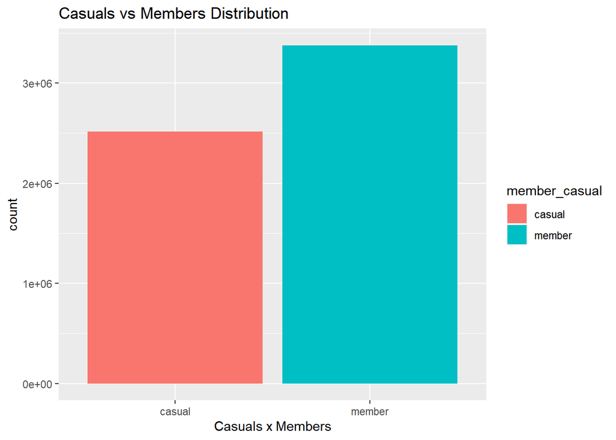

```r
ggplot(cyclistic)+
  geom_bar(mapping = aes(member_casual, fill = member_casual)) +
  labs(x = "Casuals x Members", title = "Casuals vs Members Distribution")
```

- We can see that members have a bigger proportion of the dataset.

Month

The data distributed by month

```r
cyclistic %>%
    group_by(month) %>%
    summarise(count = length(ride_id),
              '%' = (length(ride_id) / nrow(cyclistic)) * 100,
              'members_p' = (sum(member_casual == "member") / length(ride_id)) * 100,
              'casual_p' = (sum(member_casual == "casual") / length(ride_id)) * 100,
              'Member x Casual Perc Difer' = members_p - casual_p)
```

| month | count | % | members_p | casual_p | Member x Casual Perc Difer |
| --- | --- | --- | --- | --- | --- |
| 01 | 103679 | 1.758691 | 82.19504 | 17.80496 | 64.390089 |
| 02 | 115527 | 1.959667 | 81.51168 | 18.48832 | 63.023363 |
| 03 | 283758 | 4.813343 | 68.41111 | 31.58889 | 36.822222 |
| 04 | 370901 | 6.291537 | 66.00117 | 33.99883 | 32.002340 |
| 05 | 634088 | 10.755937 | 55.88357 | 44.11643 | 11.767136 |
| 06 | 768083 | 13.028874 | 52.08070 | 47.91930 | 4.161399 |
| 07 | 822469 | 13.951415 | 50.74027 | 49.25973 | 1.480542 |
| 08 | 803539 | 13.630309 | 48.72097 | 51.27903 | -2.558059 |
| 09 | 755445 | 12.814498 | 51.89365 | 48.10635 | 3.787304 |
| 10 | 630672 | 10.697992 | 59.28359 | 40.71641 | 18.567179 |

[output cut: 2 more lines]

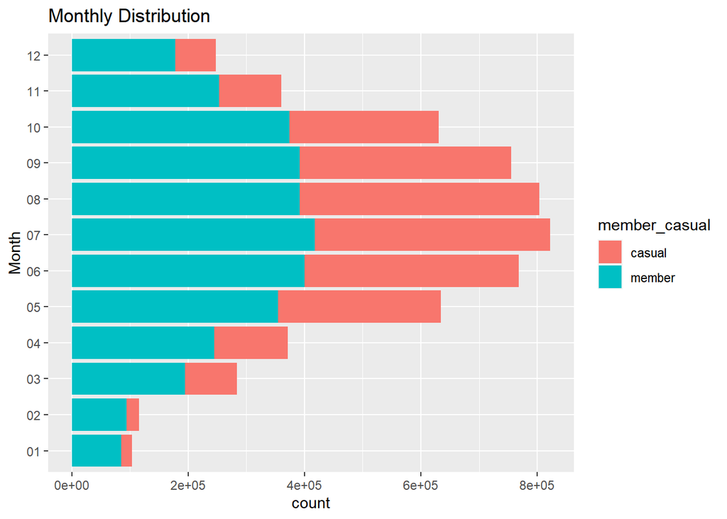

```r
ggplot(cyclistic) +
  geom_bar(mapping = aes(month, fill = member_casual)) +
  labs(x = "Month", title = "Monthly Distribution") +
  coord_flip()
```

season

The data distribution by Season

```r
cyclistic %>%
    group_by(season) %>%
    summarise(count = length(ride_id),
              '%' = (length(ride_id) / nrow(cyclistic)) * 100,
              'members_p' = (sum(member_casual == "member") / length(ride_id)) * 100,
              'casual_p' = (sum(member_casual == "casual") / length(ride_id)) * 100,
              'Member x Casual Perc Difer' = members_p - casual_p)
```

| season | count | % | members_p | casual_p | Member x Casual Perc Difer |
| --- | --- | --- | --- | --- | --- |
| Fall | 1745818 | 29.614043 | 58.36078 | 41.63922 | 16.7215598 |
| Spring | 1288747 | 21.860817 | 61.55374 | 38.44626 | 23.1074835 |
| Summer | 2394091 | 40.610598 | 50.49257 | 49.50743 | 0.9851338 |
| Winter | 466581 | 7.914542 | 76.54748 | 23.45252 | 53.0949610 |

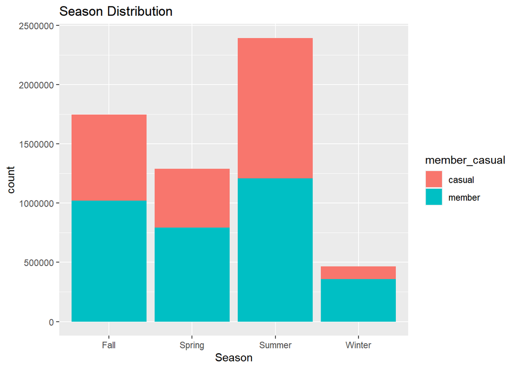

```r
ggplot(cyclistic) +
  geom_bar(mapping = aes(season, fill = member_casual)) +
  labs(x = "Season", title = "Season Distribution")
```

- There’s more data points at the summer season.

Weekday

The data distribution by weekday

```r
cyclistic %>%
    group_by(day_of_the_week) %>%
    summarise(count = length(ride_id),
              '%' = (length(ride_id) / nrow(cyclistic)) * 100,
              'members_p' = (sum(member_casual == "member") / length(ride_id)) * 100,
              'casual_p' = (sum(member_casual == "casual") / length(ride_id)) * 100,
              'Member x Casual Perc Difer' = members_p - casual_p)
```

| day_of_the_week | count | % | members_p | casual_p | Member x Casual Perc Difer |
| --- | --- | --- | --- | --- | --- |
| Friday | 813490 | 13.79911 | 57.34908 | 42.65092 | 14.698152 |
| Monday | 771305 | 13.08353 | 61.22779 | 38.77221 | 22.455579 |
| Saturday | 979795 | 16.62011 | 46.26907 | 53.73093 | -7.461867 |
| Sunday | 892332 | 15.13649 | 46.81979 | 53.18021 | -6.360413 |
| Thursday | 838014 | 14.21510 | 62.35051 | 37.64949 | 24.701019 |
| Tuesday | 796511 | 13.51109 | 65.69049 | 34.30951 | 31.380985 |
| Wednesday | 803790 | 13.63457 | 65.00317 | 34.99683 | 30.006345 |

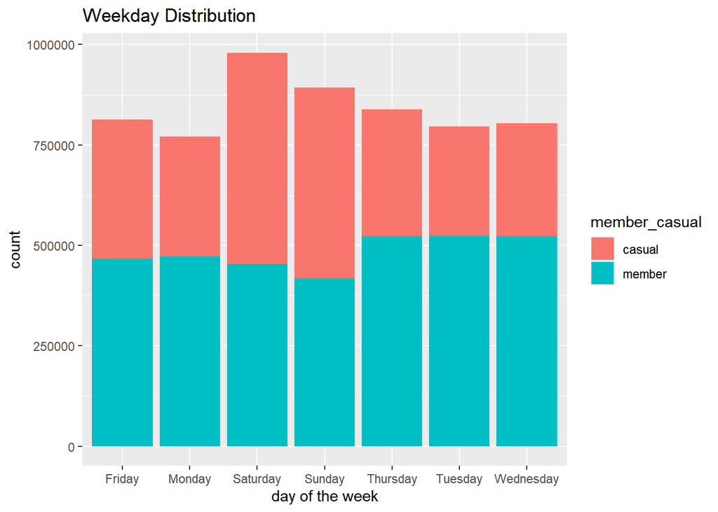

```r
ggplot(cyclistic) +
  geom_bar(mapping = aes(day_of_the_week, fill = member_casual)) +
  labs(x = "day of the week", title = "Weekday Distribution")
```

- The biggest volume of data is on the weekend specially on Saturday.
- Besides on weekend, members may have the biggest volume of data.

Hour of the day

```r
cyclistic %>%
    group_by(start_hour) %>%
    summarise(count = length(ride_id),
          '%' = (length(ride_id) / nrow(cyclistic)) * 100,
          'members_p' = (sum(member_casual == "member") / length(ride_id)) * 100,
          'casual_p' = (sum(member_casual == "casual") / length(ride_id)) * 100,
          'member_casual_perc_difer' = members_p - casual_p)
```

| start_hour | count | % | members_p | casual_p | member_casual_perc_difer |
| --- | --- | --- | --- | --- | --- |
| 00 | 87337 | 1.4814841 | 41.52765 | 58.47235 | -16.9447084 |
| 01 | 57477 | 0.9749735 | 39.76025 | 60.23975 | -20.4794961 |
| 02 | 35361 | 0.5998232 | 37.19069 | 62.80931 | -25.6186194 |
| 03 | 20791 | 0.3526745 | 38.26656 | 61.73344 | -23.4668847 |
| 04 | 18477 | 0.3134225 | 49.65092 | 50.34908 | -0.6981653 |
| 05 | 47281 | 0.8020203 | 71.85550 | 28.14450 | 43.7110044 |
| 06 | 119193 | 2.0218526 | 76.15716 | 23.84284 | 52.3143138 |
| 07 | 225385 | 3.8231711 | 76.61468 | 23.38532 | 53.2293631 |
| 08 | 273619 | 4.6413571 | 74.25946 | 25.74054 | 48.5189260 |
| 09 | 225661 | 3.8278529 | 65.17786 | 34.82214 | 30.3557106 |

[output cut: 14 more lines]

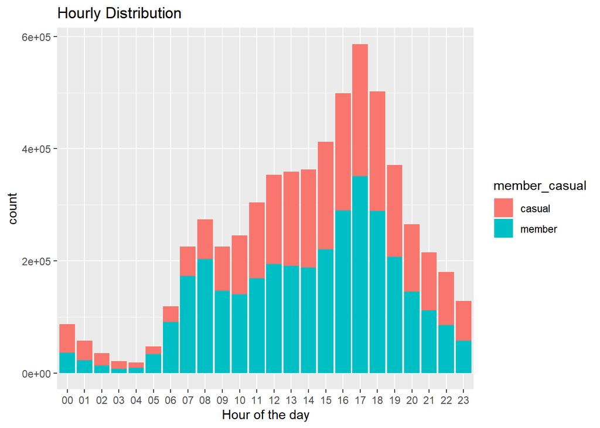

```r
ggplot(cyclistic) +
  geom_bar(mapping = aes(start_hour, fill = member_casual)) +
  labs(x = "Hour of the day", title = "Hourly Distribution")
```

- There’s a bigger volume of bikers in hours of 14 - 19.

We can expand the chart per week day

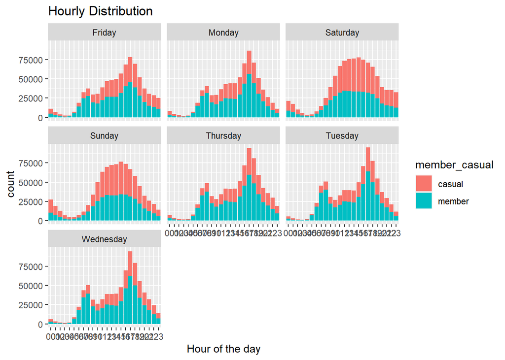

```r
ggplot(cyclistic) +
  geom_bar(mapping = aes(start_hour, fill = member_casual)) +
  labs(x = "Hour of the day", title = "Hourly Distribution") +
  facet_wrap(~ day_of_the_week)
```

Time of the day

The data distribution by time of the day

```r
cyclistic %>%
    group_by(time_of_day) %>%
    summarise(count = length(ride_id),
          '%' = (length(ride_id) / nrow(cyclistic)) * 100,
          'members_p' = (sum(member_casual == "member") / length(ride_id)) * 100,
          'casual_p' = (sum(member_casual == "casual") / length(ride_id)) * 100,
          'member_casual_perc_difer' = members_p - casual_p)
```

| time_of_day | count | % | members_p | casual_p | member_casual_perc_difer |
| --- | --- | --- | --- | --- | --- |
| Afternoon | 2573279 | 43.650137 | 55.77184 | 44.22816 | 11.543676 |
| Evening | 1662213 | 28.195864 | 53.95271 | 46.04729 | 7.905425 |
| Morning | 1393021 | 23.629601 | 66.24365 | 33.75635 | 32.487306 |
| Night | 266724 | 4.524398 | 46.25643 | 53.74357 | -7.487140 |

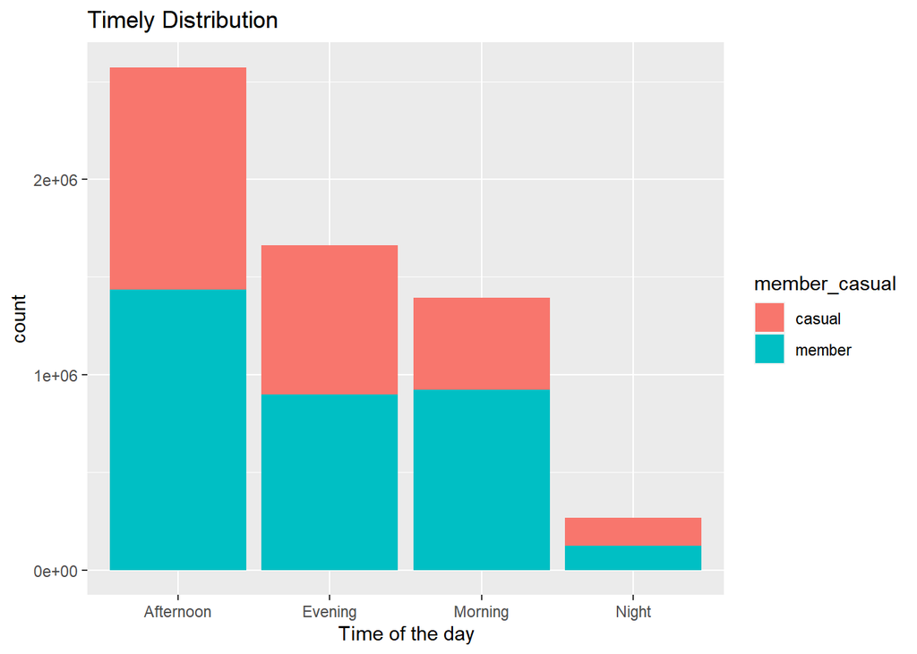

```r
ggplot(cyclistic) +
  geom_bar(mapping = aes(time_of_day, fill = member_casual)) +
  labs(x = "Time of the day", title = "Timely Distribution")
```

There is a bigger volume of bikers in afternoon and evening.

Rideable type

```r
cyclistic %>%
    group_by(rideable_type) %>%
    summarise(count = length(ride_id),
          '%' = (length(ride_id) / nrow(cyclistic)) * 100,
          'members_p' = (sum(member_casual == "member") / length(ride_id)) * 100,
          'casual_p' = (sum(member_casual == "casual") / length(ride_id)) * 100,
          'member_casual_perc_difer' = members_p - casual_p)
```

| rideable_type | count | % | members_p | casual_p | member_casual_perc_difer |
| --- | --- | --- | --- | --- | --- |
| classic_bike | 3051601 | 51.763839 | 62.97756 | 37.02244 | 25.95513 |
| docked_bike | 224943 | 3.815674 | 0.00000 | 100.00000 | -100.00000 |
| electric_bike | 2618693 | 44.420487 | 55.61228 | 44.38772 | 11.22457 |

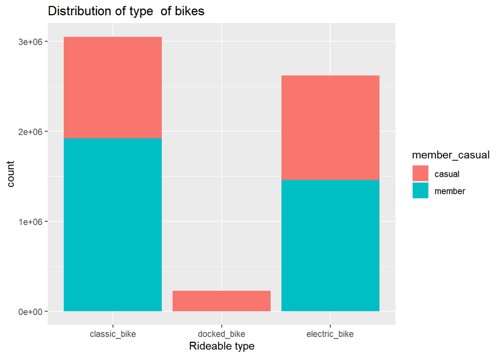

```r
ggplot(cyclistic) +
  geom_bar(mapping = aes(rideable_type, fill = member_casual)) +
  labs(x = "Rideable type", title = "Distribution of type  of bikes")
```

- We can see that no member used docked bikes.
- Classic bikes have the biggest volume of rides. But this can happen when the company may have more electric and classic bikes.

Ride length

```r
cyclistic %>%
    group_by(member_casual) %>%
    summarise(mean = mean(ride_length),
              'first_quarter' = as.numeric(quantile(ride_length, .25)),
              'median' = median(ride_length),
              'third_quarter' = as.numeric(quantile(ride_length, .75)),
              'IR' = third_quarter - first_quarter)
```

| member_casual | mean | first_quarter | median | third_quarter | IR |
| --- | --- | --- | --- | --- | --- |
| casual | 24.70195 mins | 8.183333 | 14.383333 mins | 26.26667 | 18.08333 |
| member | 12.67216 mins | 5.216667 | 9.016667 mins | 15.65000 | 10.43333 |

- Casual have more riding time than members.
- Mean and IQR is also bigger for casual.

#### Surprise of the data

One of the main surprises is how members differ from casuals when analysed from weekdays. Also that members have less riding time than casual.

#### Trends or relationships found in the data

- There are more members than casuals in the dataset.
- There are more data points in the summer season.
- There are more of a difference between the flow of members/casual from midweek to weekends.
- Members have less riding time.
- Riderss tend to prefer classic and electric bikes over docked bikes.

### Share

The share phase is usually done by building a presentation. We can share our findings over a presentation.

### Conclusion

The Google Analytics Professional Certificate thought me a lot and the R language is really useful for analyzing data (although I prefer prefer pandas). This took me more time than I expected, but it was fun.